# Practice 2

Bautista Puebla

The dataset I will use contains information about public bikes rented, along with weather, holidays and date and hour. We want to know the demand for bikes so that the public has no problem accessing the service.

```r
setwd("C:/Users/Bautista/Desktop/datasets")
data=read.csv('SeoulBikeData.csv')
seoul = data
```

We import the libraries we will use.

```r
library(tidyverse)
library(skimr)
library(forcats)
library(VIM)
library(GGally)
library(MASS)
library(caret)
library(randomForest)
library(gbm)
library(neuralnet)
library(factoextra)
library(rpart)
library(rpart.plot)
library(olsrr)

theme_set(theme_minimal()) #ggplot theme
```

## Data analysis and visualization.

First, the date as such cant be put to much use in the current state. The month information is already similar to Seasons, and the year and day arent too helpful. Therefore I chose to transform it into day of the week. We also check for NAs, and find none.

```r
seoul$Date = as.Date(seoul$Date, format = "%d/%m/%Y")
weekday = weekdays(seoul$Date)
seoul$Date = NULL

sum(is.na(seoul))
```

```
## [1] 0
```

We factorize our categorical data and relevel to keep it in order and in case we need it.

```r
seoul$Seasons = as.factor(seoul$Seasons)
seoul$Holiday = as.factor(seoul$Holiday)
seoul$Functioning.Day = as.factor(seoul$Functioning.Day)
seoul$Weekday = as.factor(weekday)
seoul$Seasons=fct_relevel(seoul$Seasons, c("Winter", "Spring", "Summer", "Autumn"))
seoul$Weekday=fct_relevel(seoul$Weekday, c("domingo", "lunes", "martes", "miércoles", "jueves", "sábado"))
```

If we check the hours of days where the bike renting system is not functioning, the bikes rented are 0 (obvious). Since we want to predict rented bikes when the system is working, we will remove the cases where it is not a functioning day.

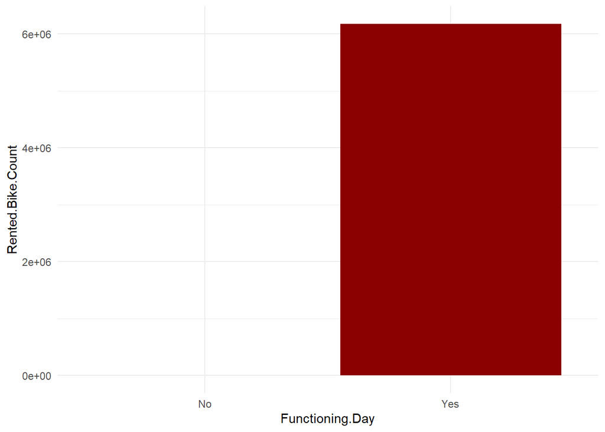

```r
ggplot(data=seoul, aes(x=Functioning.Day, y=Rented.Bike.Count)) + geom_bar(stat="identity", fill="red4")
```

```r
#not functioning days not useful
no.func = which(seoul$Functioning.Day == 'No')
seoul = seoul[-no.func,]
seoul$Functioning.Day = NULL
```

We check the boxplot of each attribute for outliers.

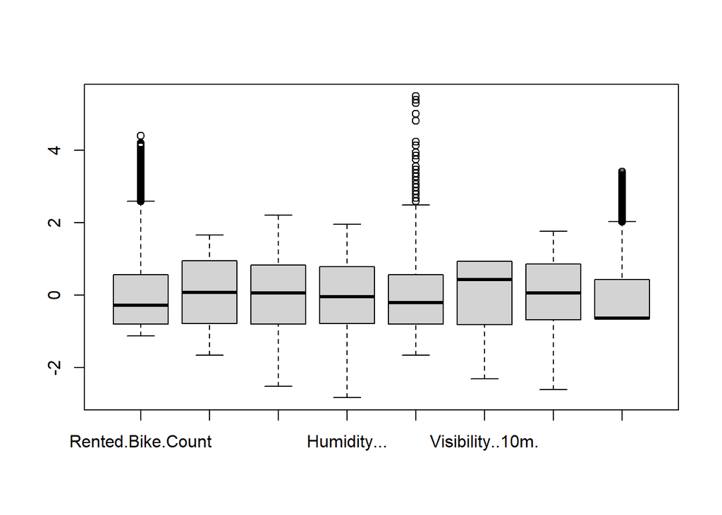

```r
boxplot(scale(seoul[,1:8]))
```

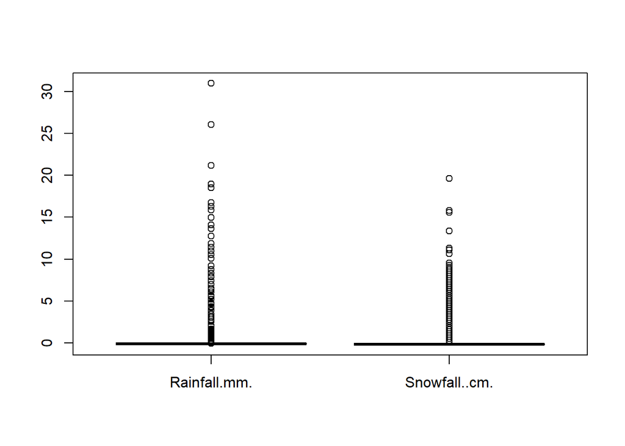

```r
boxplot(scale(seoul[,9:10]))
```

The variables that contains most outliers are rain and snow.

If we plot each against the rented bikes, we get that most snowy or rainy days are low on demand, while it varies on days where it doesnt rain or snow.

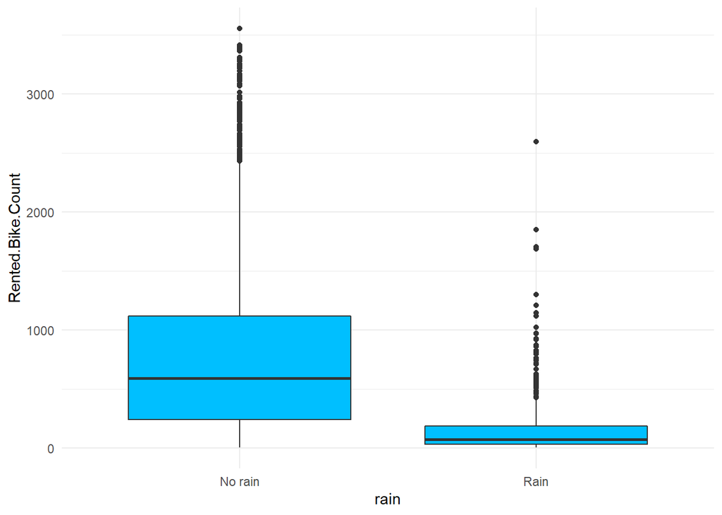

```r
rain = factor(ifelse(seoul$Rainfall.mm. == 0, "No rain",
                    "Rain"))
ggplot(data=seoul, aes(x=rain, y=Rented.Bike.Count)) + geom_boxplot(fill='deepskyblue') #boxplot for rain or not rain
```

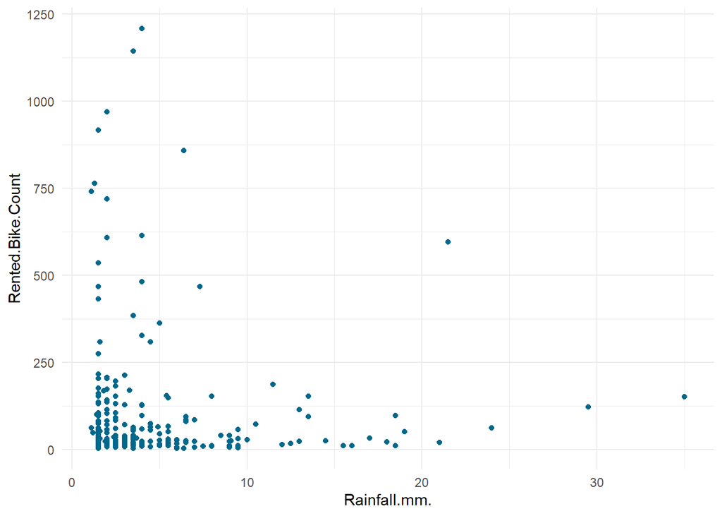

```r
rain_idx = which(seoul$Rainfall.mm. > 1)
ggplot(data=seoul[rain_idx,], aes(Rainfall.mm., Rented.Bike.Count)) + geom_point(color='deepskyblue4') #plot cases where it rains
```

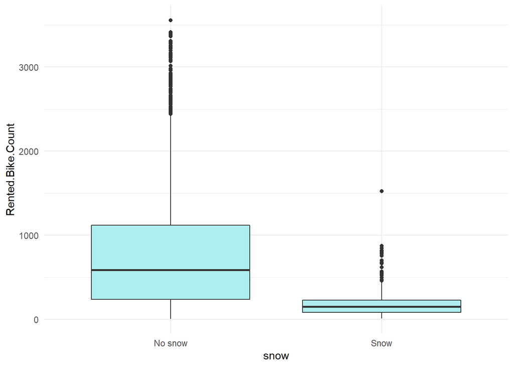

```r
snow = factor(ifelse(seoul$Snowfall..cm. == 0, "No snow",
                     "Snow"))
ggplot(data=seoul, aes(x=snow, y=Rented.Bike.Count)) + geom_boxplot(fill='paleturquoise')
```

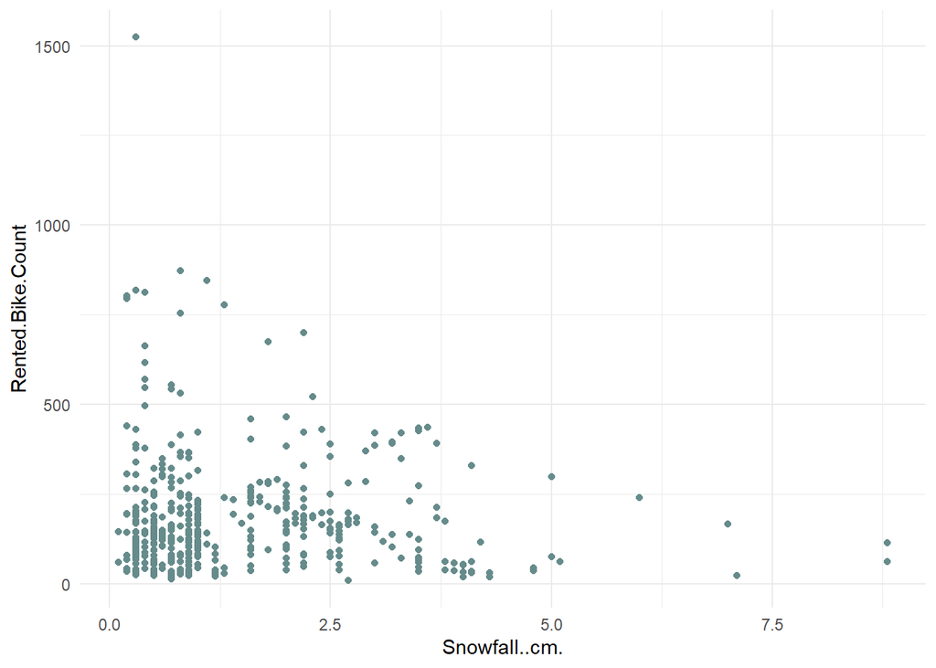

```r
snow_idx = which(seoul$Snowfall..cm. > 0)
ggplot(data=seoul[snow_idx,], aes(Snowfall..cm., Rented.Bike.Count)) + geom_point(color='paleturquoise4')
```

Boxplot on categorical variables

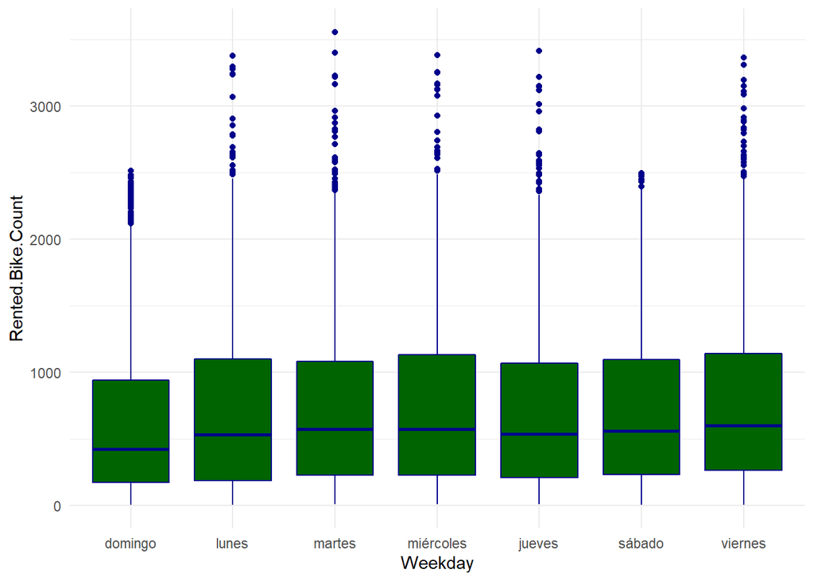

```r
ggplot(data=seoul, aes(x=Weekday, y=Rented.Bike.Count)) + geom_boxplot(fill='darkgreen', color='darkblue')
```

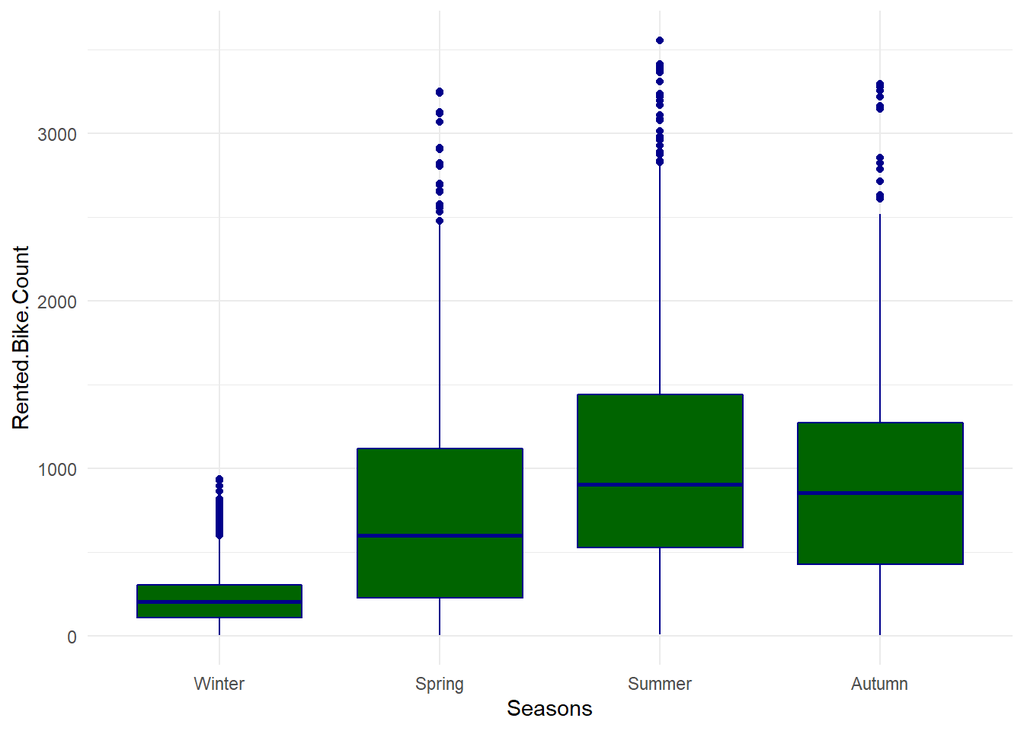

```r
ggplot(data=seoul, aes(x=Seasons, y=Rented.Bike.Count)) + geom_boxplot(fill='darkgreen', color='darkblue')
```

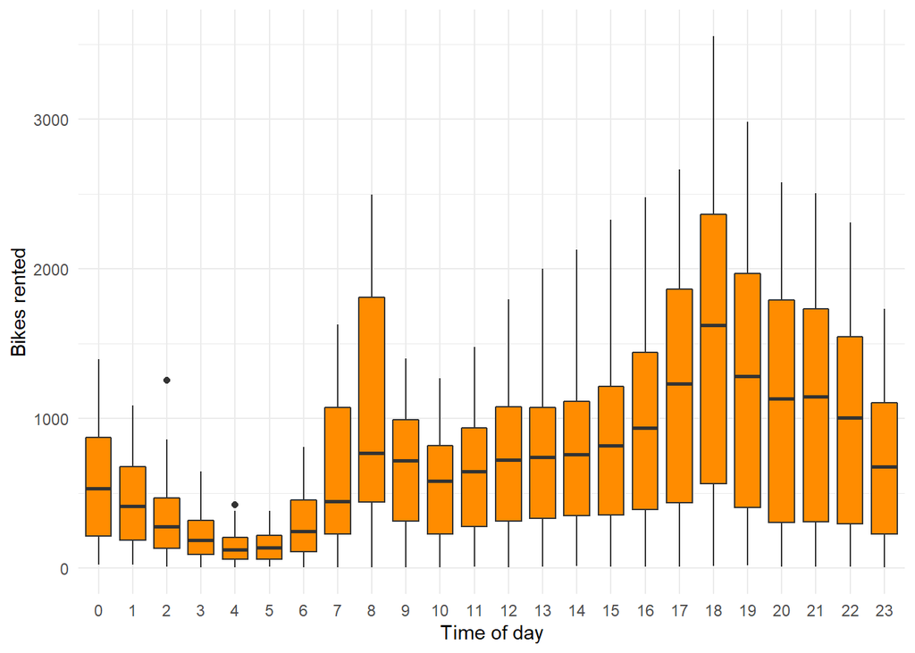

```r
ggplot(data=seoul, aes(x=as.factor(Hour), y=Rented.Bike.Count)) + geom_boxplot(fill='darkorange') + xlab('Time of day') + ylab('Bikes rented')
```

Most days are equal on demand except Sundays where it is lower. On seasons we see that clearly bikes are not very demanded on Winter, which make sense. The Hour influences the amount of bikes rented, as there is low demand during the night and high during the afternoon.

Computing the correlations it can be seen that the temperature is highly correlated with the dew point temperature, so we will remove this variable to simplify the data.

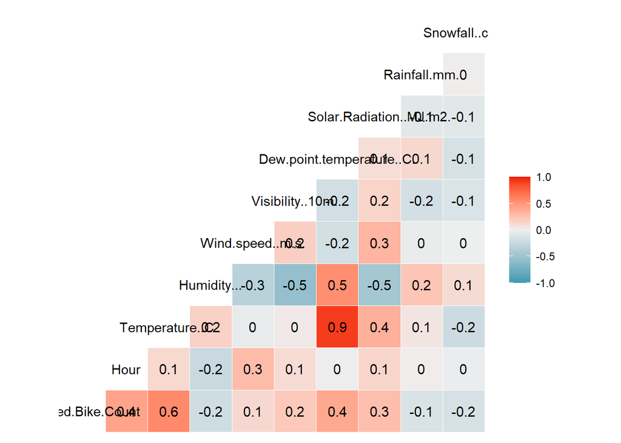

```r
ggcorr(data=seoul,label = T)
```

```r
cor(seoul$Temperature..C., seoul$Dew.point.temperature..C.)
```

```
## [1] 0.914467
```

```r
seoul$Dew.point.temperature..C. = NULL
```

The variables that correlate the most with the target are the temperature (high temperature usually means that people will take bikes) and the hour (bikes are not rented during night).

The problem with our Hour variable is that its periodicity is not fully represented. Therefore we transform the hour into two variables for the sine and cosine, and remove the original variable.

```r
seoul$xHour = sin(2*pi*seoul$Hour/24)
seoul$yHour = cos(2*pi*seoul$Hour/24)
seoul$Hour = NULL
```

Reorganizing the columns

```r
seoul= seoul[,c(2:8, 12:13, 9:11, 1)]
```

### PCA

Applying pca we can see the importance of the attributes to explain the variability of the data.

```r
pca = prcomp(seoul[,1:9], scale. = T)
summary(pca)
```

```
## Importance of components:
##                           PC1    PC2    PC3    PC4     PC5     PC6     PC7
## Standard deviation     1.6011 1.2130 1.1048 1.0590 0.93009 0.86224 0.74603
## Proportion of Variance 0.2848 0.1635 0.1356 0.1246 0.09612 0.08261 0.06184
## Cumulative Proportion  0.2848 0.4483 0.5839 0.7086 0.80467 0.88727 0.94911
##                            PC8     PC9
## Standard deviation     0.53648 0.41251
## Proportion of Variance 0.03198 0.01891
## Cumulative Proportion  0.98109 1.00000
```

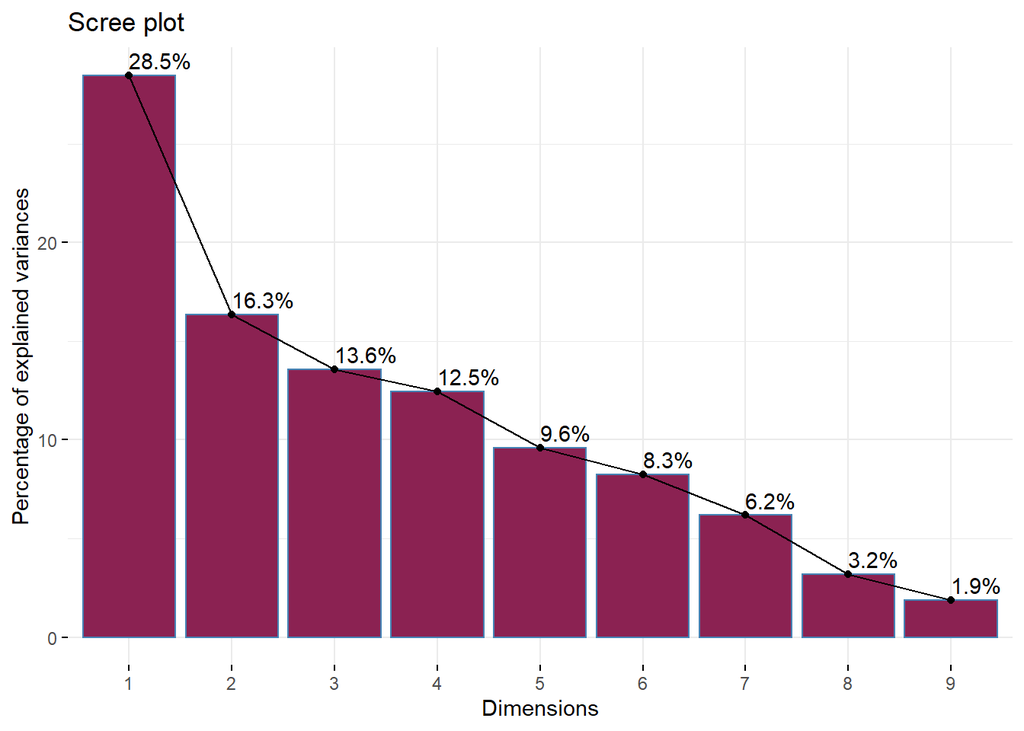

```r
fviz_screeplot(pca, addlabels = TRUE, barfill = 'violetred4' )
```

The first three components explain ~60% of the variability. Here are the compositions of each component:

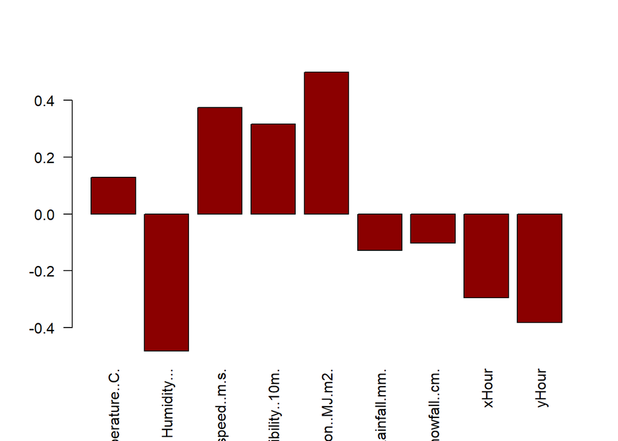

```r
barplot(pca$rotation[,1], las=2, col="red4")
```

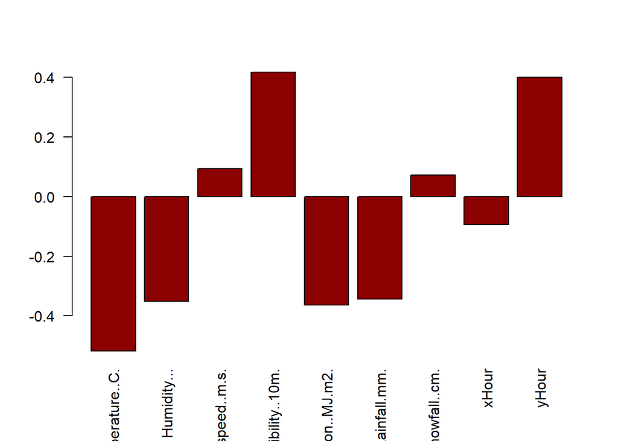

```r
barplot(pca$rotation[,2], las=2, col="red4")
```

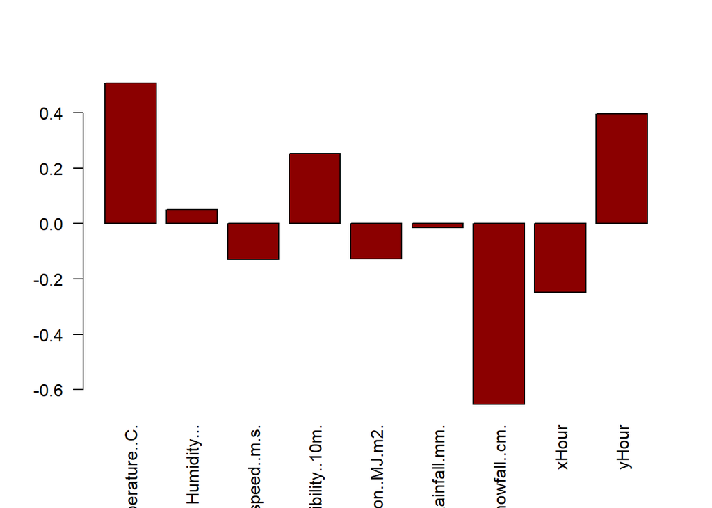

```r
barplot(pca$rotation[,3], las=2, col="red4")
```

The first component differenciates sunny hours with cloudy or night hours. The second one is not as clear, but it seems to correlate negatively the temperature and other factors with visibility and an hour vector. The third one depends heavily on the snowfall and temperature, seems to be a ‘winter’ indicator.

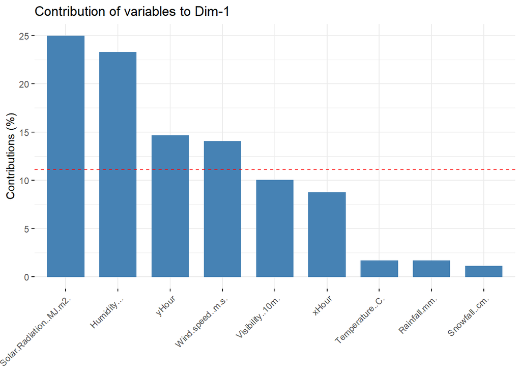

```r
fviz_contrib(pca, choice = "var", axes = 1)
```

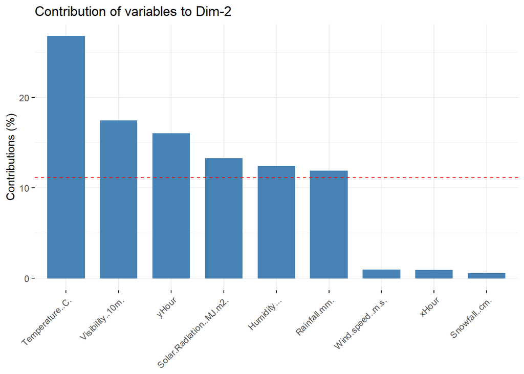

```r
fviz_contrib(pca, choice = "var", axes = 2)
```

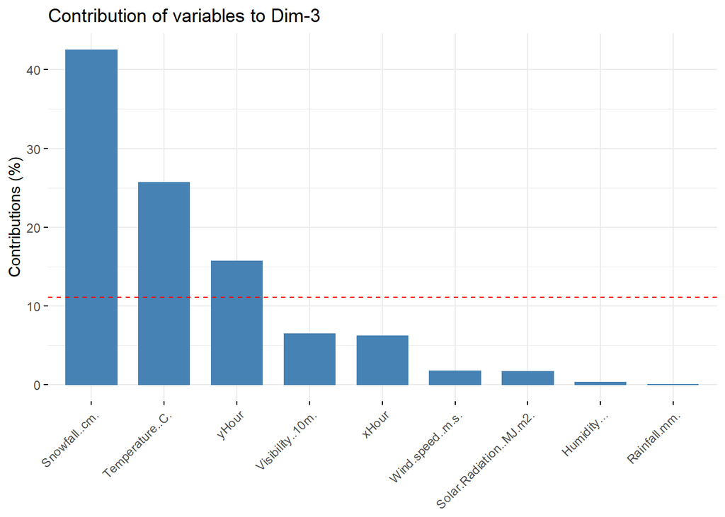

```r
fviz_contrib(pca, choice = "var", axes = 3)
```

Plotting the density of the target,

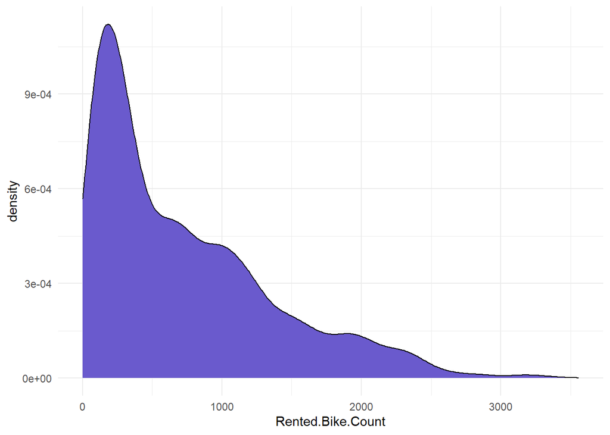

```r
ggplot(seoul, aes(x=Rented.Bike.Count)) + geom_density(fill='slateblue')
```

The distribution of the demand seems to be skewed to lower values, so we will use the square root to visualize the information better.

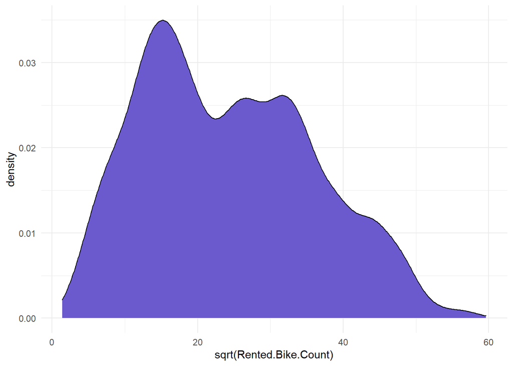

```r
ggplot(seoul, aes(x=sqrt(Rented.Bike.Count))) + geom_density(fill='slateblue')
```

## Classification

On the graph we can see a slight division between two distributions. We will take that treshold to categorize the target variable in two: High and Low demand. This way, we can make apply of classification tools.

```r
df = seoul
df$Bike.Demand = factor(ifelse(df$Rented.Bike.Count <= 500, "Low",
                                        "High"))
df$Rented.Bike.Count = NULL
```

Then we split the dataframe in 70% train and 30% test.

```r
split=createDataPartition(df$Bike.Demand, p = 0.7, list = FALSE)

df_tr = df[split,]
df_ts = df[-split,]
```

### LDA

We will first apply a simple model to see what are the coefficients and get an initial accuracy.

```r
lda.model = lda(Bike.Demand ~ ., data=df_tr)
lda.model
```

```
## Call:
## lda(Bike.Demand ~ ., data = df_tr)
##
## Prior probabilities of groups:
##     High      Low
## 0.519406 0.480594
##
## Group means:
##      Temperature..C. Humidity... Wind.speed..m.s. Visibility..10m.
## High       19.656920    54.58902         1.802437         1532.277
## Low         5.375246    62.23385         1.629775         1308.671
##      Solar.Radiation..MJ.m2. Rainfall.mm. Snowfall..cm.      xHour      yHour
## High               0.8955913   0.01416504   0.003736192 -0.2187323 -0.1292221
## Low                0.2104424   0.30403792   0.170330056  0.2449344  0.1420312
##      SeasonsSpring SeasonsSummer SeasonsAutumn HolidayNo Holiday Weekdaylunes
## High     0.2803769     0.3755686     0.3203379         0.9668616    0.1455491
## Low      0.2292837     0.1320225     0.1372893         0.9343399    0.1446629
##      Weekdaymartes Weekdaymiércoles Weekdayjueves Weekdaysábado Weekdayviernes
## High     0.1435997        0.1448993     0.1419753     0.1413255      0.1530214
## Low      0.1288624        0.1393961     0.1425562     0.1408006      0.1358848
##
## Coefficients of linear discriminants:
##                                   LD1
## Temperature..C.         -0.0486994581
## Humidity...              0.0184350606
## Wind.speed..m.s.         0.0857405513
## Visibility..10m.        -0.0000155204
## Solar.Radiation..MJ.m2. -0.1257041592
## Rainfall.mm.             0.1848267943
## Snowfall..cm.            0.0057065125
## xHour                    0.6571587026
## yHour                    0.2095877322
## SeasonsSpring           -1.4463817952
## SeasonsSummer           -1.6348083366
## SeasonsAutumn           -1.9878563027
## HolidayNo Holiday       -0.3096160705
## Weekdaylunes            -0.2310317409
## Weekdaymartes           -0.3807352837
## Weekdaymiércoles        -0.3438160174
## Weekdayjueves           -0.3159127796
## Weekdaysábado           -0.2363625802
## Weekdayviernes          -0.3696207602
```

```r
prediction = predict(lda.model, newdata=df_ts)$class
confusionMatrix(prediction, df_ts$Bike.Demand)$table
```

```
##           Reference
## Prediction High  Low
##       High 1172  211
##       Low   147 1009
```

```r
acc_lda=confusionMatrix(prediction, df_ts$Bike.Demand)$overall[1]
print(acc_lda)
```

```
##  Accuracy
## 0.8589996
```

The accuracy is high for a simple model, but that is because it is easy to predict from the data we provide, especially on winter where most of the days there is a low demand. We have seen before that the rainfall and snowfall variables are not very linear, so we discretize both and try again.

```r
rain = factor(ifelse(seoul$Rainfall.mm. == 0, "No rain",
                     "Rain"))
snow = factor(ifelse(seoul$Snowfall..cm. == 0, "No snow",
                     "Snow"))
df_tr2=df_tr
df_tr2$Rainfall.mm.=rain = factor(ifelse(df_tr2$Rainfall.mm. == 0, "No rain",
                                 "Rain"))
df_tr2$Snowfall..cm. = factor(ifelse(df_tr2$Snowfall..cm. == 0, "No snow",
                     "Snow"))
df_ts2=df_ts
df_ts2$Rainfall.mm.=rain = factor(ifelse(df_ts2$Rainfall.mm. == 0, "No rain",
                                         "Rain"))
df_ts2$Snowfall..cm. = factor(ifelse(df_ts2$Snowfall..cm. == 0, "No snow",
                                     "Snow"))
lda.model = lda(Bike.Demand ~ ., data=df_tr2)
lda.model
```

```
## Call:
## lda(Bike.Demand ~ ., data = df_tr2)
##
## Prior probabilities of groups:
##     High      Low
## 0.519406 0.480594
##
## Group means:
##      Temperature..C. Humidity... Wind.speed..m.s. Visibility..10m.
## High       19.656920    54.58902         1.802437         1532.277
## Low         5.375246    62.23385         1.629775         1308.671
##      Solar.Radiation..MJ.m2. Rainfall.mm.Rain Snowfall..cm.Snow      xHour
## High               0.8955913      0.009421702       0.003248863 -0.2187323
## Low                0.2104424      0.114115169       0.109550562  0.2449344
##           yHour SeasonsSpring SeasonsSummer SeasonsAutumn HolidayNo Holiday
## High -0.1292221     0.2803769     0.3755686     0.3203379         0.9668616
## Low   0.1420312     0.2292837     0.1320225     0.1372893         0.9343399
##      Weekdaylunes Weekdaymartes Weekdaymiércoles Weekdayjueves Weekdaysábado
## High    0.1455491     0.1435997        0.1448993     0.1419753     0.1413255
## Low     0.1446629     0.1288624        0.1393961     0.1425562     0.1408006
##      Weekdayviernes
## High      0.1530214
## Low       0.1358848
##
## Coefficients of linear discriminants:
##                                   LD1
## Temperature..C.         -4.846871e-02
## Humidity...              1.220668e-02
## Wind.speed..m.s.         6.969369e-02
## Visibility..10m.        -1.021896e-05
## Solar.Radiation..MJ.m2. -1.042486e-01
## Rainfall.mm.Rain         1.778788e+00
## Snowfall..cm.Snow       -1.151752e-01
## xHour                    7.015227e-01
## yHour                    2.686557e-01
## SeasonsSpring           -1.532043e+00
## SeasonsSummer           -1.679524e+00
## SeasonsAutumn           -2.006487e+00
## HolidayNo Holiday       -2.692840e-01
## Weekdaylunes            -2.451466e-01
## Weekdaymartes           -3.596810e-01
## Weekdaymiércoles        -3.294941e-01
## Weekdayjueves           -2.875945e-01
## Weekdaysábado           -2.240000e-01
## Weekdayviernes          -3.816565e-01
```

```r
prediction = predict(lda.model, newdata=df_ts2)$class
confusionMatrix(prediction, df_ts2$Bike.Demand)$table
```

```
##           Reference
## Prediction High  Low
##       High 1191  209
##       Low   128 1011
```

```r
acc_lda2=confusionMatrix(prediction, df_ts2$Bike.Demand)$overall[1]
print(acc_lda2)
```

```
##  Accuracy
## 0.8672706
```

Less false negatives and almost the same false positives, better accuracy. We will keep it this way for categorization.

```r
df_tr=df_tr2
df_ts=df_ts2
```

### Decision trees

We use decision trees to examine which variables it takes into account. First with a shallow tree:

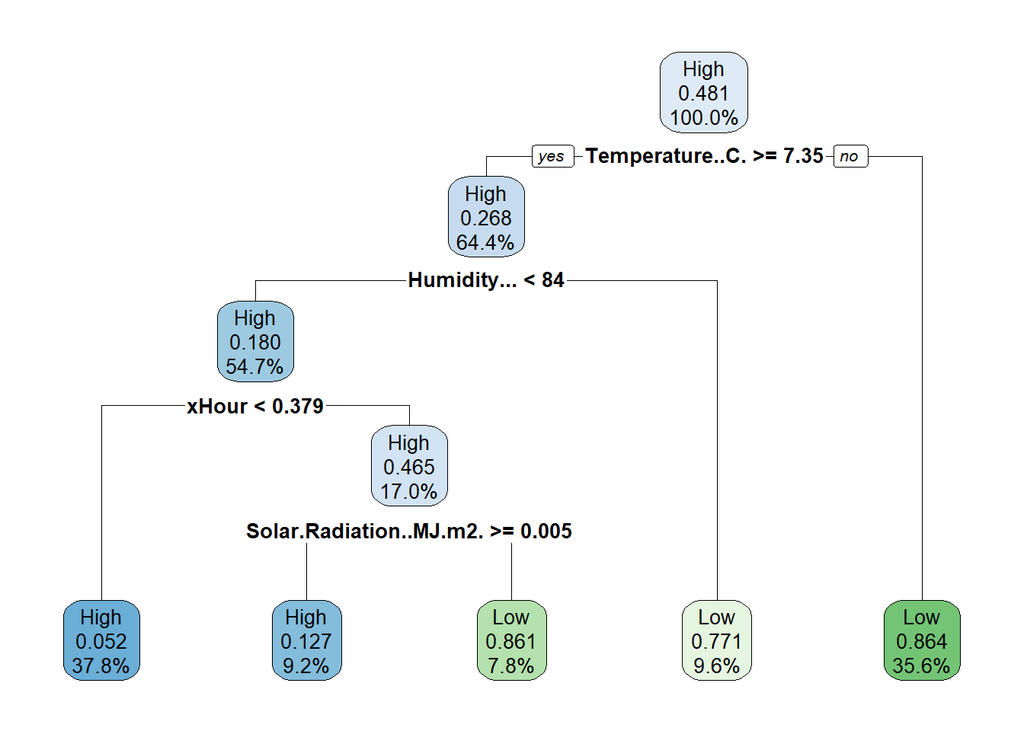

```r
control = rpart.control(minsplit = 30, maxdepth = 10, cp=0.01)
dtFit = rpart(Bike.Demand ~ ., data=df_tr, method = "class", control = control)
rpart.plot(dtFit, digits=3)
```

With caret, we use a cross-validated tree to compare accuracies.

```r
model=Bike.Demand ~ . #
ctrl = trainControl(method='cv', number = 5, classProbs = TRUE, verboseIter=T)
caret.fit = train(model,
                   data = df_tr,
                   method = "rpart",
                   control=rpart.control(minsplit = 30, maxdepth = 16),
                   trControl = trainControl(method = "cv", number = 5),
                   tuneLength=10)
caret.fit
```

```
## CART
##
## 5926 samples
##   12 predictor
##    2 classes: 'High', 'Low'
##
## No pre-processing
## Resampling: Cross-Validated (5 fold)
## Summary of sample sizes: 4740, 4741, 4740, 4741, 4742
## Resampling results across tuning parameters:
##
##   cp           Accuracy   Kappa
##   0.001580056  0.9093849  0.8185939
##   0.001931180  0.9085413  0.8169076
##   0.001989700  0.9046577  0.8091795
##   0.002808989  0.9014497  0.8029169
##   0.003160112  0.9014497  0.8029169
##   0.004564607  0.9007751  0.8015255
##   0.010884831  0.8830619  0.7665932
##   0.058637640  0.8476345  0.6950461
##   0.108497191  0.8116858  0.6212423
##   0.539676966  0.6667061  0.3146309
##
## Accuracy was used to select the optimal model using the largest value.
## The final value used for the model was cp = 0.001580056.
```

```r
model_nl=Bike.Demand ~ .+xHour:yHour
caret.fit_nl = train(model,
                   data = df_tr,
                   method = "rpart",
                   control=rpart.control(minsplit = 30, maxdepth = 16),
                   trControl = trainControl(method = "cv", number = 5),
                   tuneLength=10)
caret.fit_nl
```

```
## CART
##
## 5926 samples
##   12 predictor
##    2 classes: 'High', 'Low'
##
## No pre-processing
## Resampling: Cross-Validated (5 fold)
## Summary of sample sizes: 4742, 4742, 4740, 4740, 4740
## Resampling results across tuning parameters:
##
##   cp           Accuracy   Kappa
##   0.001580056  0.9127515  0.8252691
##   0.001931180  0.9115699  0.8229865
##   0.001989700  0.9114016  0.8226622
##   0.002808989  0.9073481  0.8144752
##   0.003160112  0.9063357  0.8126279
##   0.004564607  0.9032995  0.8065710
##   0.010884831  0.8882825  0.7769763
##   0.058637640  0.8587493  0.7173099
##   0.108497191  0.8012246  0.5996065
##   0.539676966  0.6171260  0.2087066
##
## Accuracy was used to select the optimal model using the largest value.
## The final value used for the model was cp = 0.001580056.
```

We try now the accuracy on testing set.

```r
dtPred = predict(caret.fit, df_ts, type = "raw")
CM = confusionMatrix(factor(dtPred), df_ts$Bike.Demand)
CM
```

```
## Confusion Matrix and Statistics
##
##           Reference
## Prediction High  Low
##       High 1205  116
##       Low   114 1104
##
##                Accuracy : 0.9094
##                  95% CI : (0.8976, 0.9203)
##     No Information Rate : 0.5195
##     P-Value [Acc > NIR] : <2e-16
##
##                   Kappa : 0.8185
##
##  Mcnemar's Test P-Value : 0.9474
##
##             Sensitivity : 0.9136
##             Specificity : 0.9049
##          Pos Pred Value : 0.9122
##          Neg Pred Value : 0.9064
##              Prevalence : 0.5195
##          Detection Rate : 0.4746
##    Detection Prevalence : 0.5203
##       Balanced Accuracy : 0.9092
##
##        'Positive' Class : High
##
```

### Logistic regression

Lets now try a GLM as a logistic regression.

```r
logit.model = glm(model, data=df_tr, family = 'binomial')
summary(logit.model)
```

```
##
## Call:
## glm(formula = model, family = "binomial", data = df_tr)
##
## Deviance Residuals:
##     Min       1Q   Median       3Q      Max
## -3.6962  -0.3530  -0.0657   0.3543   3.7280
##
## Coefficients:
##                           Estimate Std. Error z value Pr(>|z|)
## (Intercept)              3.488e+00  3.789e-01   9.206  < 2e-16 ***
## Temperature..C.         -1.048e-01  8.537e-03 -12.274  < 2e-16 ***
## Humidity...              2.937e-02  3.538e-03   8.302  < 2e-16 ***
## Wind.speed..m.s.         3.046e-01  5.486e-02   5.553 2.81e-08 ***
## Visibility..10m.         1.044e-04  8.909e-05   1.171 0.241416
## Solar.Radiation..MJ.m2. -1.701e-01  1.200e-01  -1.418 0.156317
## Rainfall.mm.Rain         4.245e+00  2.649e-01  16.028  < 2e-16 ***
## Snowfall..cm.Snow        2.202e+00  4.809e-01   4.578 4.69e-06 ***
## xHour                    2.096e+00  9.593e-02  21.853  < 2e-16 ***
## yHour                    1.023e+00  1.057e-01   9.681  < 2e-16 ***
## SeasonsSpring           -3.807e+00  2.064e-01 -18.448  < 2e-16 ***
## SeasonsSummer           -4.215e+00  2.846e-01 -14.812  < 2e-16 ***
## SeasonsAutumn           -4.948e+00  2.244e-01 -22.048  < 2e-16 ***
## HolidayNo Holiday       -8.463e-01  2.166e-01  -3.907 9.34e-05 ***
## Weekdaylunes            -5.792e-01  1.619e-01  -3.577 0.000348 ***
## Weekdaymartes           -9.621e-01  1.642e-01  -5.860 4.62e-09 ***
## Weekdaymiércoles        -9.048e-01  1.636e-01  -5.530 3.21e-08 ***
## Weekdayjueves           -7.170e-01  1.614e-01  -4.441 8.94e-06 ***
## Weekdaysábado           -6.628e-01  1.608e-01  -4.121 3.78e-05 ***
## Weekdayviernes          -1.041e+00  1.627e-01  -6.402 1.53e-10 ***
## ---
## Signif. codes:  0 '***' 0.001 '**' 0.01 '*' 0.05 '.' 0.1 ' ' 1
##
## (Dispersion parameter for binomial family taken to be 1)
##
##     Null deviance: 8206.3  on 5925  degrees of freedom
## Residual deviance: 3387.6  on 5906  degrees of freedom
## AIC: 3427.6
##
## Number of Fisher Scoring iterations: 7
```

We can see that visibility and solar radiation are not as significant on this model. Predicting:

```r
probability = predict(logit.model,newdata=df_ts, type='response')
prediction = as.factor(ifelse(probability > 0.5,"Low","High"))
confusionMatrix(prediction, df_ts$Bike.Demand)
```

```
## Confusion Matrix and Statistics
##
##           Reference
## Prediction High  Low
##       High 1156  145
##       Low   163 1075
##
##                Accuracy : 0.8787
##                  95% CI : (0.8654, 0.8911)
##     No Information Rate : 0.5195
##     P-Value [Acc > NIR] : <2e-16
##
##                   Kappa : 0.7571
##
##  Mcnemar's Test P-Value : 0.3327
##
##             Sensitivity : 0.8764
##             Specificity : 0.8811
##          Pos Pred Value : 0.8885
##          Neg Pred Value : 0.8683
##              Prevalence : 0.5195
##          Detection Rate : 0.4553
##    Detection Prevalence : 0.5124
##       Balanced Accuracy : 0.8788
##
##        'Positive' Class : High
##
```

The resulting accuracy and kappa is lower than the obtained on decision trees. We can do a small visualization of how it performs when using the temperature only.

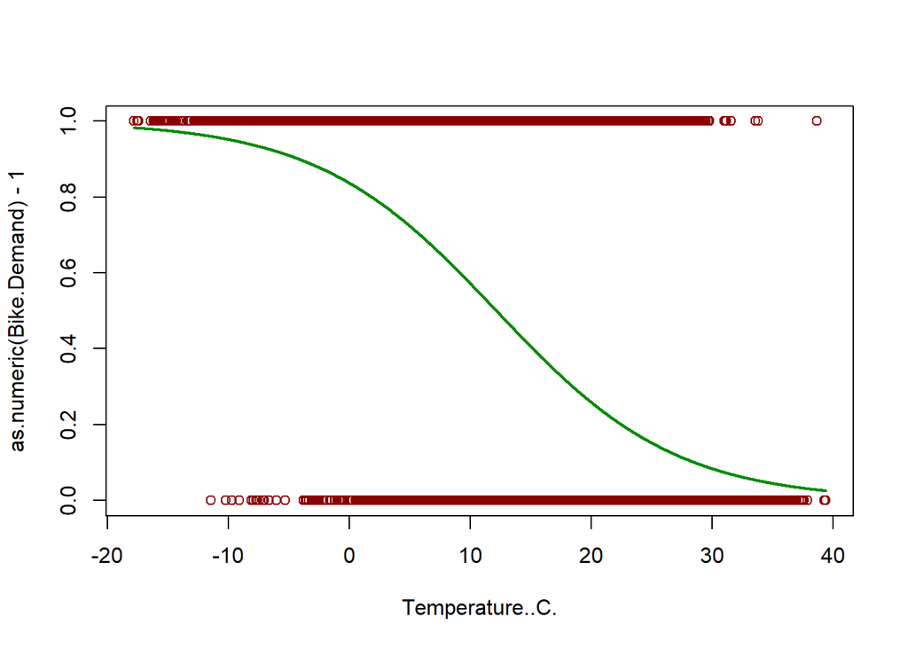

```r
fit = glm(Bike.Demand ~ Temperature..C., data=df_tr, family=binomial)
newdat = data.frame(Temperature..C.=seq(min(df_tr$Temperature..C.), max(df_tr$Temperature..C.),len=2539))
newdat$demand = predict(fit, newdat, type = 'response')
plot(as.numeric(Bike.Demand)-1 ~ Temperature..C., data=df_tr, col="red4")
lines(demand ~ Temperature..C., newdat, col="green4", lwd=2)
```

We see that it has a lot of overlapping, so we clearly need more variables, but it gives us an idea of how the temperature affects the data. Accuracy of this model:

```r
probability = predict(fit,newdata=df_ts, type='response')
prediction = as.factor(ifelse(probability > 0.5,"Low","High"))
confusionMatrix(prediction, df_ts$Bike.Demand)
```

```
## Confusion Matrix and Statistics
##
##           Reference
## Prediction High  Low
##       High 1019  300
##       Low   300  920
##
##                Accuracy : 0.7637
##                  95% CI : (0.7467, 0.7801)
##     No Information Rate : 0.5195
##     P-Value [Acc > NIR] : <2e-16
##
##                   Kappa : 0.5267
##
##  Mcnemar's Test P-Value : 1
##
##             Sensitivity : 0.7726
##             Specificity : 0.7541
##          Pos Pred Value : 0.7726
##          Neg Pred Value : 0.7541
##              Prevalence : 0.5195
##          Detection Rate : 0.4013
##    Detection Prevalence : 0.5195
##       Balanced Accuracy : 0.7633
##
##        'Positive' Class : High
##
```

### SVM

Using svm:

```r
# already tuned, it is computationally expensive so I decided to add only the resulting parameters.
svm_grid =   expand.grid(cost = c(1),
                          Loss = c(5),
                          weight = c(5))

svm_mod = train(model,
                 method = "svmLinearWeights2",
                 trControl = ctrl,
                 tuneGrid = svm_grid,
                 data = df_tr)
svm_mod
```

```
## L2 Regularized Linear Support Vector Machines with Class Weights
##
## 5926 samples
##   12 predictor
##    2 classes: 'High', 'Low'
##
## No pre-processing
## Resampling: Cross-Validated (5 fold)
## Summary of sample sizes: 4741, 4740, 4741, 4741, 4741
## Resampling results:
##
##   Accuracy   Kappa
##   0.6699515  0.3567706
##
## Tuning parameter 'cost' was held constant at a value of 1
## Tuning
##  parameter 'Loss' was held constant at a value of 5
## Tuning parameter
##  'weight' was held constant at a value of 5
```

### Random Forests

Seeing the good results on decision trees, we should study the performance on random forests.

```r
rf.train = train(model,
                  method = "rf",
                  data = df_tr,
                  preProcess = c("center", "scale"),
                  ntree = 400,
                  tuneGrid = expand.grid(mtry=c(2,4,8)),
                  trControl = ctrl)
rf.train
```

```
## Random Forest
##
## 5926 samples
##   12 predictor
##    2 classes: 'High', 'Low'
##
## Pre-processing: centered (19), scaled (19)
## Resampling: Cross-Validated (5 fold)
## Summary of sample sizes: 4741, 4740, 4740, 4741, 4742
## Resampling results across tuning parameters:
##
##   mtry  Accuracy   Kappa
##   2     0.9282855  0.8564210
##   4     0.9345301  0.8689014
##   8     0.9338549  0.8675269
##
## Accuracy was used to select the optimal model using the largest value.
## The final value used for the model was mtry = 4.
```

As expected, since random forest is a bigger application of decision trees, very good performance on random forests for a .93 accuracy and a 0.87 kappa.

```r
rf_pred = predict(rf.train, df_ts, type = "raw")
CM = confusionMatrix(rf_pred, df_ts$Bike.Demand)
CM
```

```
## Confusion Matrix and Statistics
##
##           Reference
## Prediction High  Low
##       High 1230   66
##       Low    89 1154
##
##                Accuracy : 0.939
##                  95% CI : (0.9289, 0.948)
##     No Information Rate : 0.5195
##     P-Value [Acc > NIR] : < 2e-16
##
##                   Kappa : 0.8778
##
##  Mcnemar's Test P-Value : 0.07721
##
##             Sensitivity : 0.9325
##             Specificity : 0.9459
##          Pos Pred Value : 0.9491
##          Neg Pred Value : 0.9284
##              Prevalence : 0.5195
##          Detection Rate : 0.4844
##    Detection Prevalence : 0.5104
##       Balanced Accuracy : 0.9392
##
##        'Positive' Class : High
##
```

### Gradient boosting

And with gradient boosting:

```r
xgb_grid = expand.grid(
  nrounds = 1000,
  eta = c(0.01, 0.1), # c(0.01,0.05,0.1)
  max_depth = c(6,8),
  gamma = 1,
  colsample_bytree = c(0.6, 0.8),
  min_child_weight = 1,
  subsample = 1
)

xgb.train = train(Bike.Demand ~ .,  data=df_tr,
                  trControl = ctrl,
                  tuneGrid = xgb_grid,
                  preProcess = c("center", "scale"),
                  method = "xgbTree"
)
```

```
## Fitting nrounds = 1000, max_depth = 8, eta = 0.1, gamma = 1, colsample_bytree = 0.6, min_child_weight = 1, subsample = 1 on full training set
```

```r
xgb.train
```

```
## eXtreme Gradient Boosting
##
## 5926 samples
##   12 predictor
##    2 classes: 'High', 'Low'
##
## Pre-processing: centered (19), scaled (19)
## Resampling: Cross-Validated (5 fold)
## Summary of sample sizes: 4740, 4740, 4741, 4742, 4741
## Resampling results across tuning parameters:
##
##   eta   max_depth  colsample_bytree  Accuracy   Kappa
##   0.01  6          0.6               0.9399213  0.8796625
##   0.01  6          0.8               0.9392470  0.8783080
##   0.01  8          0.6               0.9397528  0.8793213
##   0.01  8          0.8               0.9432971  0.8864019
##   0.10  6          0.6               0.9404275  0.8806631
##   0.10  6          0.8               0.9427912  0.8854039
##   0.10  8          0.6               0.9441423  0.8881106
##   0.10  8          0.8               0.9441411  0.8881024
##
## Tuning parameter 'nrounds' was held constant at a value of 1000
##  parameter 'min_child_weight' was held constant at a value of 1
##
## Tuning parameter 'subsample' was held constant at a value of 1
## Accuracy was used to select the optimal model using the largest value.
## The final values used for the model were nrounds = 1000, max_depth = 8, eta
##  = 0.1, gamma = 1, colsample_bytree = 0.6, min_child_weight = 1 and subsample
##  = 1.
```

As always, very good accuracy thanks to fine parameter tuning. With test set:

```r
xgb_pred = predict(xgb.train, df_ts, type = "raw")
CM = confusionMatrix(xgb_pred, df_ts$Bike.Demand)
CM
```

```
## Confusion Matrix and Statistics
##
##           Reference
## Prediction High  Low
##       High 1253   63
##       Low    66 1157
##
##                Accuracy : 0.9492
##                  95% CI : (0.9399, 0.9574)
##     No Information Rate : 0.5195
##     P-Value [Acc > NIR] : <2e-16
##
##                   Kappa : 0.8982
##
##  Mcnemar's Test P-Value : 0.8602
##
##             Sensitivity : 0.9500
##             Specificity : 0.9484
##          Pos Pred Value : 0.9521
##          Neg Pred Value : 0.9460
##              Prevalence : 0.5195
##          Detection Rate : 0.4935
##    Detection Prevalence : 0.5183
##       Balanced Accuracy : 0.9492
##
##        'Positive' Class : High
##
```

We went from 86% accuracy on LDA to a 95% accuracy with almost 0.9 kappa with this very accurate algorithm. However, gradient boosting is not as explainable as other simpler models like logistic regression or decision trees. I decided not to include ensemble on classification because the results obtained were the same as gradient boosting.

## Regression

For regression, we will keep the rain and snow as it was previously, as it helps us be more specific on days it rains/snows and it doesnt create dummy variables. We split data as previously.

```r
split=createDataPartition(seoul$Rented.Bike.Count, p = 0.7, list = FALSE)

r_tr = seoul[split,]
r_ts = seoul[-split,]
```

As seen previously, the variable most correlated with the target was Temperature, so we will use that for now

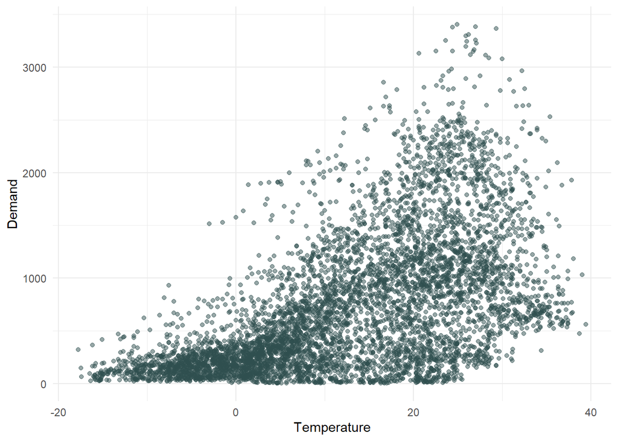

```r
my.formula=sqrt(Rented.Bike.Count)~Temperature..C
ggplot(r_tr, aes(x=Temperature..C., y=Rented.Bike.Count)) + xlab("Temperature")+ ylab("Demand") +  geom_point(alpha=0.5, color='darkslategray')
```

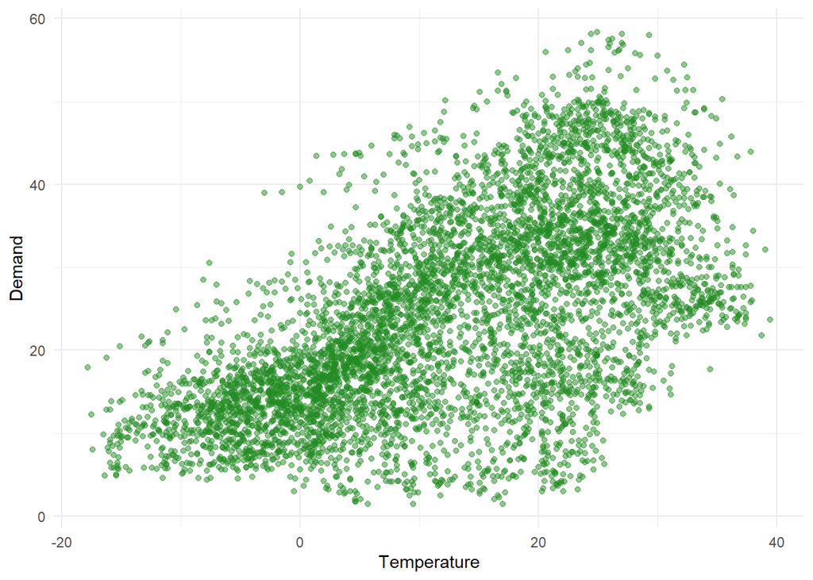

```r
ggplot(r_tr, aes(x=Temperature..C., y=sqrt(Rented.Bike.Count))) + xlab("Temperature")+ ylab("Demand") +  geom_point(alpha=0.5, color='forestgreen')
```

### Univariable linear regression

We compute a linear regression with this variable:

```r
linFit = lm(sqrt(Rented.Bike.Count)~Temperature..C., data=r_tr)
summary(linFit)
```

```
##
## Call:
## lm(formula = sqrt(Rented.Bike.Count) ~ Temperature..C., data = r_tr)
##
## Residuals:
##     Min      1Q  Median      3Q     Max
## -27.264  -6.066   0.079   5.764  27.084
##
## Coefficients:
##                 Estimate Std. Error t value Pr(>|t|)
## (Intercept)     16.92657    0.17738   95.43   <2e-16 ***
## Temperature..C.  0.57939    0.01009   57.40   <2e-16 ***
## ---
## Signif. codes:  0 '***' 0.001 '**' 0.01 '*' 0.05 '.' 0.1 ' ' 1
##
## Residual standard error: 9.478 on 5925 degrees of freedom
## Multiple R-squared:  0.3573, Adjusted R-squared:  0.3572
## F-statistic:  3294 on 1 and 5925 DF,  p-value: < 2.2e-16
```

R2 is very low, but it gives us some explainability. Plotting the residuals and a quantile:

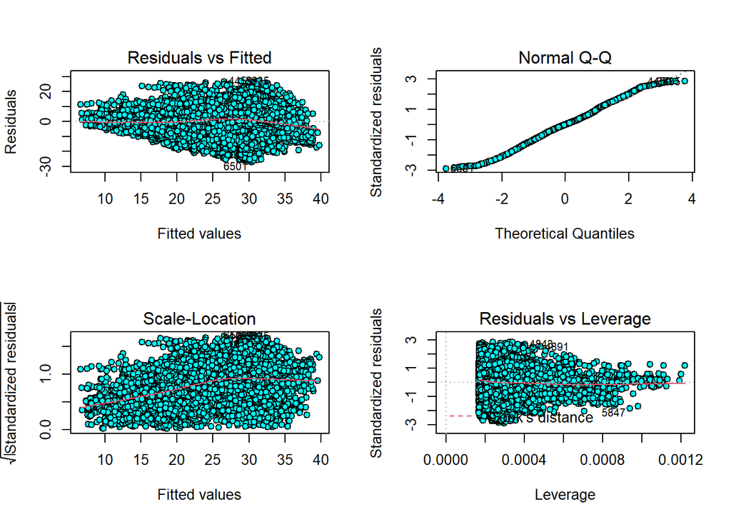

```r
par(mfrow=c(2,2))
plot(linFit, pch=21 ,bg='cyan',cex=1)
```

We get a very good Q-Q plot, but our model has no homoscedasticity (residuals are bigger with temperature). We can not take the log or square root of the temperature, since it has negative values.

```r
pred = predict(linFit, r_ts)^2
cor(r_ts$Rented.Bike.Count, pred)^2
```

```
## [1] 0.307433
```

We get a low R^2 on prediction as well. We must use a multiple regression.

### Multiple linear regression

Linear model using the three most correlated variables and seasons:

```r
linFit = lm(sqrt(Rented.Bike.Count) ~ Temperature..C. + xHour*yHour + Seasons + Solar.Radiation..MJ.m2., data=r_tr)
summary(linFit)
```

```
##
## Call:
## lm(formula = sqrt(Rented.Bike.Count) ~ Temperature..C. + xHour *
##     yHour + Seasons + Solar.Radiation..MJ.m2., data = r_tr)
##
## Residuals:
##     Min      1Q  Median      3Q     Max
## -32.921  -3.737   0.044   4.024  23.523
##
## Coefficients:
##                         Estimate Std. Error t value Pr(>|t|)
## (Intercept)             14.45729    0.20984  68.895  < 2e-16 ***
## Temperature..C.          0.35678    0.01831  19.480  < 2e-16 ***
## xHour                   -5.81215    0.15104 -38.482  < 2e-16 ***
## yHour                   -0.06641    0.20831  -0.319     0.75
## SeasonsSpring            4.12453    0.39142  10.537  < 2e-16 ***
## SeasonsSummer            4.49330    0.59098   7.603 3.34e-14 ***
## SeasonsAutumn            8.06576    0.40842  19.749  < 2e-16 ***
## Solar.Radiation..MJ.m2.  2.04693    0.18355  11.152  < 2e-16 ***
## xHour:yHour             -8.82114    0.28687 -30.749  < 2e-16 ***
## ---
## Signif. codes:  0 '***' 0.001 '**' 0.01 '*' 0.05 '.' 0.1 ' ' 1
##
## Residual standard error: 7.563 on 5918 degrees of freedom
## Multiple R-squared:  0.5914, Adjusted R-squared:  0.5908
## F-statistic:  1071 on 8 and 5918 DF,  p-value: < 2.2e-16
```

R2 = 0.59, a big improvement on what we had before. yHour seems to be not significant, but its relation with xHour is. We must establish a benchmark model to see how much we progress from it.

```r
#benchmark
benchFit = lm(sqrt(Rented.Bike.Count) ~ 1, r_tr)
predictions = predict(benchFit, r_ts)^2
RMSE = sqrt(mean((predictions - r_ts$Rented.Bike.Count)^2))
RMSE
```

```
## [1] 662.3136
```

Now on model selection, we choose all variables, the hour relation, and we will consider the square root of the solar radiation, since it is very skewed too.

```r
linFit = lm(sqrt(Rented.Bike.Count) ~ . + xHour:yHour + sqrt(Solar.Radiation..MJ.m2.), data=r_tr)
ols_step_both_aic(linFit)
```

```
##
##
##                                               Stepwise Summary
## ----------------------------------------------------------------------------------------------------------
## Variable                          Method        AIC          RSS          Sum Sq       R-Sq      Adj. R-Sq
## ----------------------------------------------------------------------------------------------------------
## Temperature..C.                  addition    43483.756    532287.062    295967.626    0.35734      0.35723
## xHour                            addition    42295.963    435476.853    392777.835    0.47422      0.47405
## xHour:yHour                      addition    41549.010    383783.555    444471.133    0.53664      0.53640
## Humidity...                      addition    40611.481    327524.226    500730.462    0.60456      0.60429
## Seasons                          addition    39951.803    292729.557    535525.131    0.64657      0.64615
## Rainfall.mm.                     addition    39549.543    273429.177    554825.511    0.66987      0.66943
## Weekday                          addition    39447.034    268197.261    560057.427    0.67619      0.67542
## Holiday                          addition    39401.836    266070.018    562184.670    0.67876      0.67794
## sqrt(Solar.Radiation..MJ.m2.)    addition    39384.121    265186.466    563068.222    0.67982      0.67896
## Solar.Radiation..MJ.m2.          addition    39172.066    255780.088    572474.600    0.69118      0.69029
## yHour                            addition    39090.679    252206.720    576047.968    0.69550      0.69457
## Wind.speed..m.s.                 addition    39080.759    251699.989    576554.699    0.69611      0.69513
## ----------------------------------------------------------------------------------------------------------
```

```r
predictions = (predict(linFit, r_ts)^2)
cor(r_ts$Rented.Bike.Count, predictions)^2
```

```
## [1] 0.6738605
```

```r
RMSE = sqrt(mean((predictions - r_ts$Rented.Bike.Count)^2))
RMSE
```

```
## [1] 376.8262
```

Very good improvement on RMSE.

### Stepwise regression

Now with caret, stepwise regression.

```r
model = sqrt(Rented.Bike.Count) ~ Temperature..C. + xHour*yHour + Seasons + sqrt(Solar.Radiation..MJ.m2.)+ Solar.Radiation..MJ.m2. + Humidity...+ Rainfall.mm. + Weekday + Holiday + Wind.speed..m.s.
ctrl = trainControl(method = "cv",
                     number = 5)

results = data.frame(demand = sqrt(r_ts$Rented.Bike.Count))
```

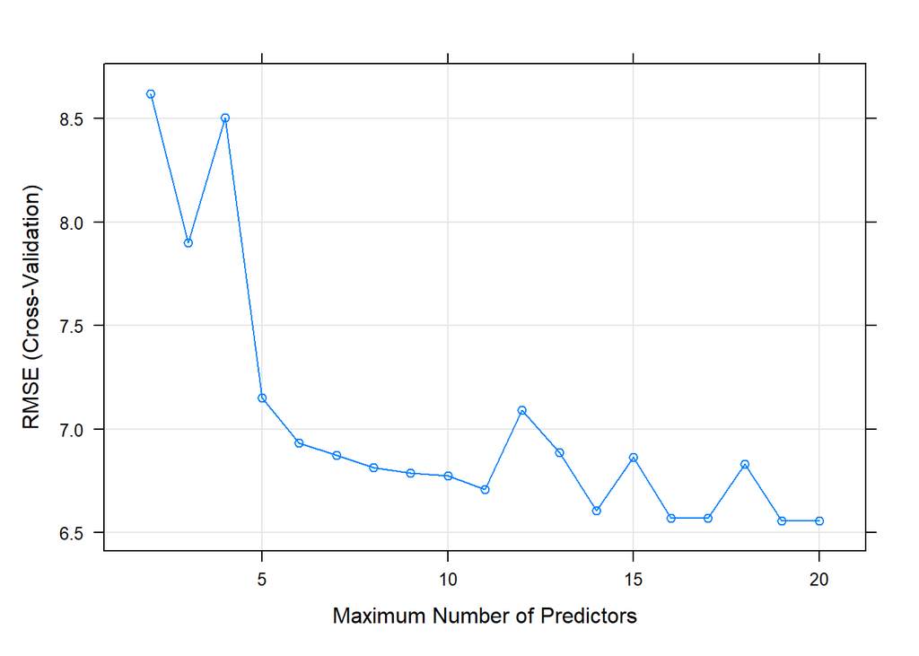

```r
step_tune = train(model,
                   data = r_tr,
                   method = "leapSeq",
                   preProc=c('scale', 'center'),
                   tuneGrid = expand.grid(nvmax = 2:20),
                   trControl = ctrl)
plot(step_tune)
```

Selecting all coeficients is best.

```r
coef(step_tune$finalModel, step_tune$bestTune$nvmax)
```

```
##                   (Intercept)               Temperature..C.
##                    24.2557562                     5.3968028
##                         xHour                         yHour
##                    -2.8812346                     1.8228444
##                 SeasonsSpring                 SeasonsSummer
##                     1.9656568                     1.9891210
##                 SeasonsAutumn sqrt(Solar.Radiation..MJ.m2.)
##                     3.4068637                     8.0632295
##       Solar.Radiation..MJ.m2.                   Humidity...
##                    -6.1369512                    -2.9146148
##                  Rainfall.mm.                  Weekdaylunes
##                    -1.7974658                     0.4550014
##                 Weekdaymartes              Weekdaymiércoles
##                     0.9131938                     0.9625023
##                 Weekdayjueves                 Weekdaysábado
##                     0.6871825                     0.5248751
##                Weekdayviernes             HolidayNo Holiday
##                     1.0079169                     0.5745252
##              Wind.speed..m.s.                   xHour:yHour
##                    -0.3443612                    -3.1509776
```

```r
results$stepwise <- predict(step_tune, r_ts)
postResample(pred = results$stepwise, obs=results$demand)
```

```
##      RMSE  Rsquared       MAE
## 6.5943393 0.6950725 5.0802590
```

The results are the same as before on R squared…

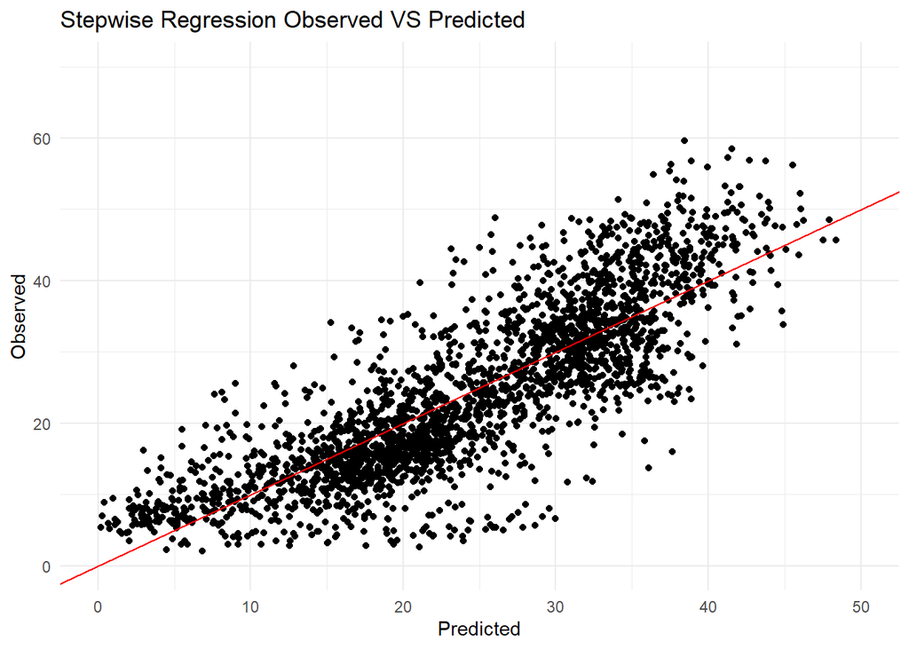

```r
qplot(results$stepwise, results$demand) +
  labs(title="Stepwise Regression Observed VS Predicted", x="Predicted", y="Observed") +
  lims(x = c(0, 50), y = c(0, 70)) +
  geom_abline(intercept = 0, slope = 1, colour = "red")
```

We can see that it predicts very high values (remember its squared) when the actual demand is vey low.

### Statistical learning tools

Next, I used some of the statistical learning algorithm we learned during class, with very similar results between them, and not much explainability.

Ridge regression:

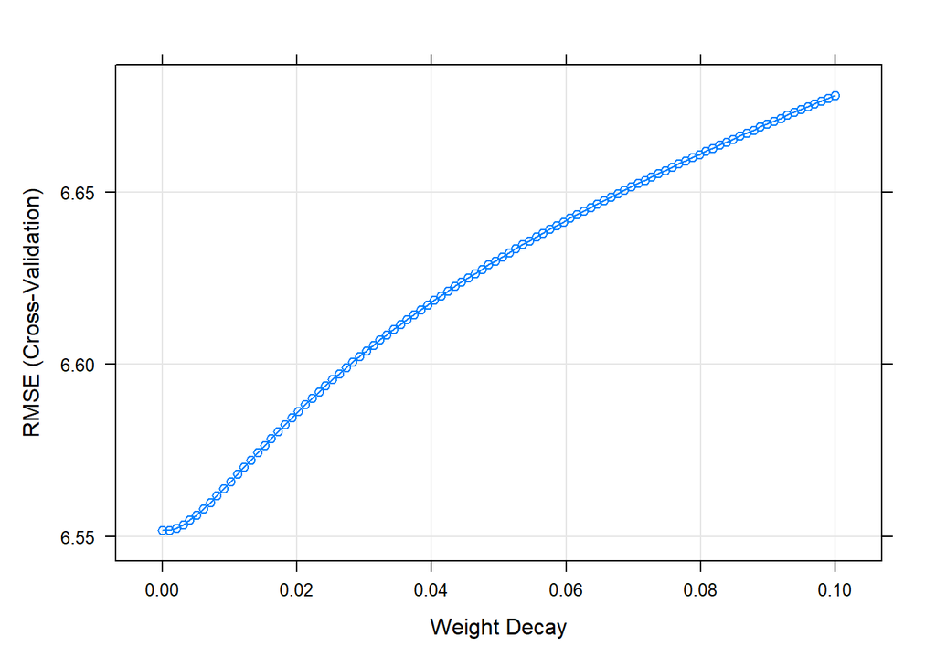

```r
ridge_grid = expand.grid(lambda = seq(0, .1, length = 100)) #grid of lambdas for tuning
ridge_tune = train(model,
                  data = r_tr,
                  method='ridge',
                  preProc=c('scale','center'),
                  tuneGrid = ridge_grid,
                  trControl=ctrl)
plot(ridge_tune)
```

The performance metric seems to improve when lambda is very low.

```r
ridge_tune$bestTune
```

```
##   lambda
## 1      0
```

So, with lambda 0. If we predict and compare with the previous results, it has not improved significantly.

```r
results$ridge = predict(ridge_tune, r_ts)
postResample(pred = results$ridge,  obs = results$demand)
```

```
##      RMSE  Rsquared       MAE
## 6.5943393 0.6950725 5.0802590
```

Lasso:

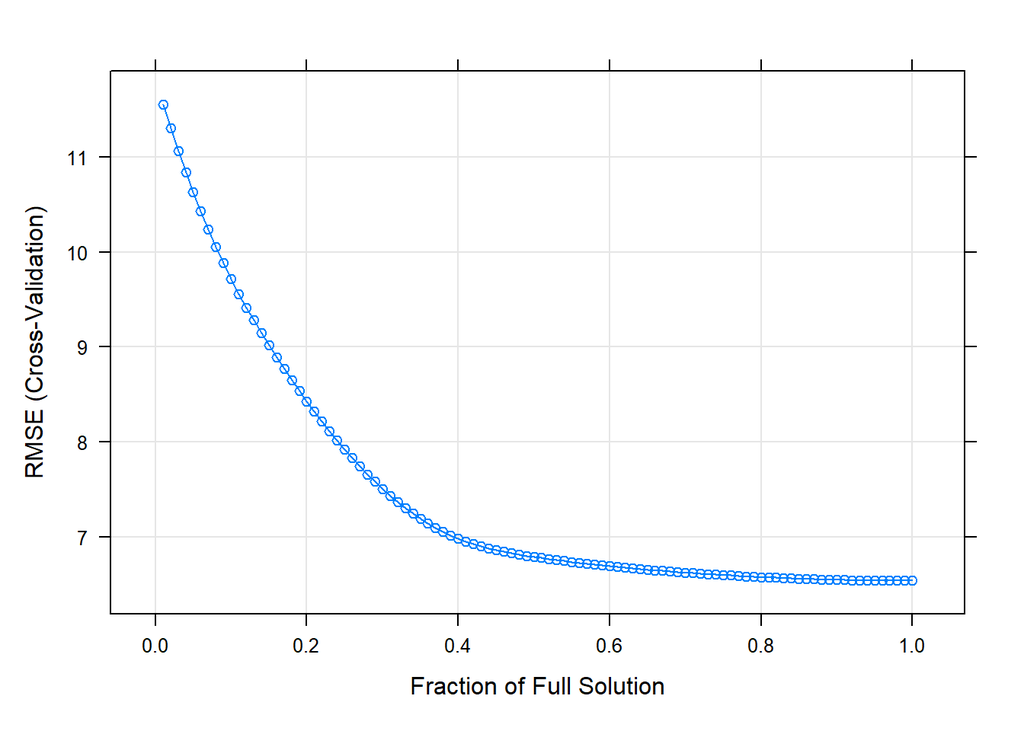

```r
lasso_grid = expand.grid(fraction = seq(.01, 1, length = 100))

lasso_tune = train(model,
                    data = r_tr,
                    method='lasso',
                    preProc=c('scale','center'),
                    tuneGrid = lasso_grid,
                    trControl=ctrl)
plot(lasso_tune)
```

```r
lasso_tune$bestTune
```

```
##     fraction
## 100        1
```

Similarly, lasso also improves when its parameter reachs the limit, and the performance is the same:

```r
results$lasso = predict(lasso_tune, r_ts)
postResample(pred = results$lasso,  obs = results$demand)
```

```
##      RMSE  Rsquared       MAE
## 6.5943393 0.6950725 5.0802590
```

Elastic grid:

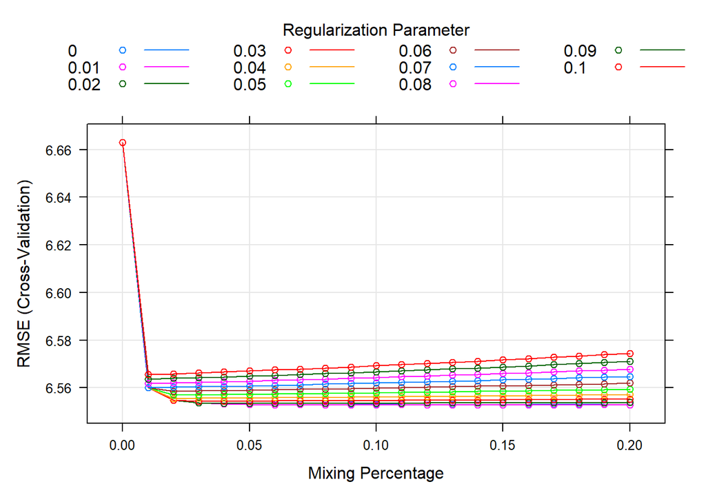

```r
elastic_grid = expand.grid(alpha = seq(0, .2, 0.01), lambda = seq(0, .1, 0.01))

glmnet_tune = train(model,
                     data = r_tr,
                     method='glmnet',
                     preProc=c('scale','center'),
                     tuneGrid = elastic_grid,
                     trControl=ctrl)

plot(glmnet_tune)
```

```r
glmnet_tune$bestTune
```

```
##     alpha lambda
## 133  0.12      0
```

```r
results$glmnet = predict(glmnet_tune, r_ts)

postResample(pred = results$glmnet,  obs = results$demand)
```

```
##      RMSE  Rsquared       MAE
## 6.5953548 0.6950023 5.0757493
```

Performs very similar to the previous two.

### KNN

The machine learning tools seem to overshadow the performance of statistical learning tools, as it can be seen when we use knn:

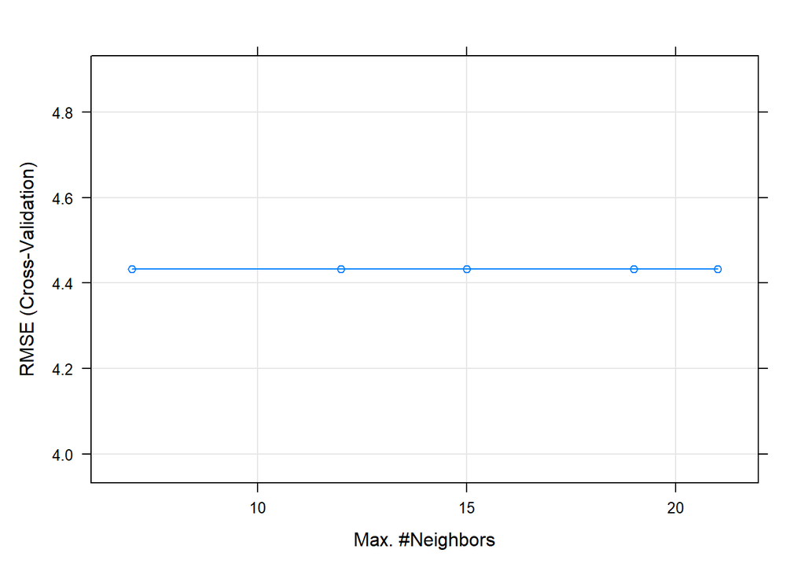

```r
knn_tune = train(model,
                  data = r_tr,
                  method = "kknn",
                  preProc=c('scale','center'),
                  tuneGrid = expand.grid(kmax=c(7,12,15,19,21),distance=c(1),kernel='optimal'),
                  trControl = ctrl)
plot(knn_tune)
```

The metric barely changes with the different max number of neighbors.

```r
results$knn = predict(knn_tune, r_ts)

postResample(pred = results$knn,  obs = results$demand)
```

```
##      RMSE  Rsquared       MAE
## 4.2170874 0.8762061 2.9061463
```

Compared to previous models, R2 increased by 0.19 and the residual mean square error is a third less of what it was with the previous three tools. Now, taking the most accurate methods on classification and applying them to regression,

### Random Forests

Random forests:

```r
rf_tune = train(model,
                 data = r_tr,
                 method = "rf",
                 preProc=c('scale','center'),
                 trControl = ctrl,
                 ntree = 100,
                 tuneGrid = data.frame(mtry=c(12)), #very expensive to tune, so i put the best parameters
                 importance = TRUE)
```

Best number of variables is 12

```r
results$rf = predict(rf_tune, r_ts)

postResample(pred = results$rf,  obs = results$demand)
```

```
##      RMSE  Rsquared       MAE
## 3.8132354 0.8983484 2.5622283
```

The performance is even better than KNN. Plus, it allows us for some explainability by variable importance:

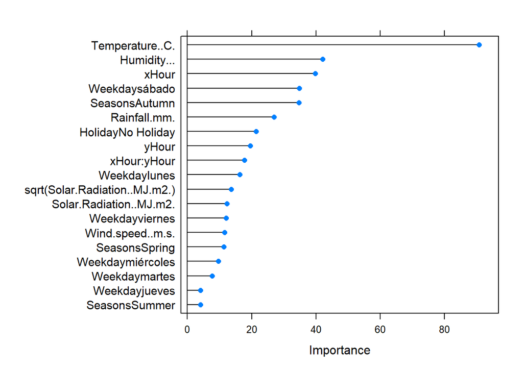

```r
plot(varImp(rf_tune, scale = F), scales = list(y = list(cex = .95)))
```

From the graph, it looks like dividing by day of the week was a good choice.